# Explore Weather Trends

July25,2019

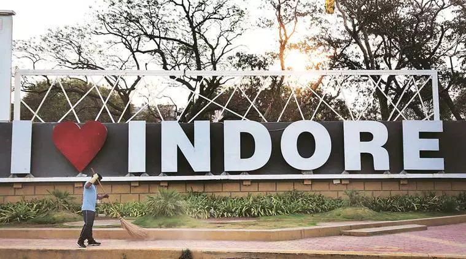

Picture Reference:https://indianexpress.com/article/india/indore-indias-cleanest-city-swachh-bharat-mission-5662774/

Udacity - Data Analyst Nanodegree

Project -1, Explore Data Trends

Submitted By: Shreyas Shukla

#### GOALS:

1. Extraction of data from database using SQL and export as CSV file
2. Make a chart/graph visualisation
3. Observation and Inference based on graphs

#### TOOLS USED:

1. SQL
2. Python
3. ANACONDA - Jupyter Notebook
4. Google Sheets

#### STEPS:

##### Extract data from database using SQL

```python
from IPython.core.display import Image
```

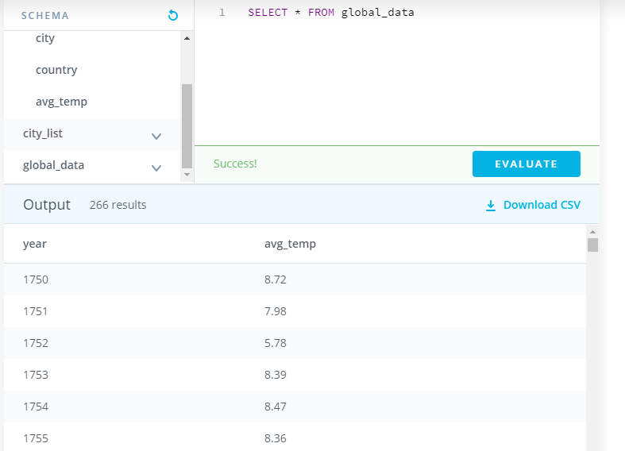

```python
Image(filename= 'C:/Users/shrey/Desktop/Global.png')
```

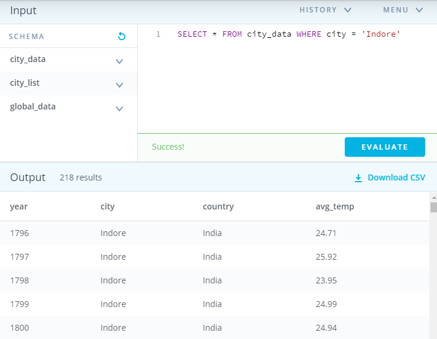

```python
Image(filename= 'C:/Users/shrey/Desktop/Indore.png')
```

##### *Import required python libraries*

```python
import pandas as pd
import numpy as np
import seaborn as sns
import matplotlib.pyplot as plt
```

###### Read extracted csv files of Global mean temperature and that of Indore city. Get maximum and minimum temperatures from both the datasets

```python
Global = pd.read_csv('C:/Users/shrey/Desktop/UDACITY/Project1/Global.csv')
```

```python
Indore = pd.read_csv('C:/Users/shrey/Desktop/UDACITY/Project1/Indore.csv')
```

```python
Indore.head(5)
```

|  | year | city | country | avg_temp |
| --- | --- | --- | --- | --- |
| 0 | 1796 | Indore | India | 24.71 |
| 1 | 1797 | Indore | India | 25.92 |
| 2 | 1798 | Indore | India | 23.95 |
| 3 | 1799 | Indore | India | 24.99 |
| 4 | 1800 | Indore | India | 24.94 |

```python
Indore.max()
```

```
year          2013
city        Indore
country      India
avg_temp     26.41
dtype: object
```

```python
Indore.min()
```

```
year          1796
city        Indore
country      India
avg_temp      19.6
dtype: object
```

```python
Global.head(5)
```

|  | year | avg_temp |
| --- | --- | --- |
| 0 | 1750 | 8.72 |
| 1 | 1751 | 7.98 |
| 2 | 1752 | 5.78 |
| 3 | 1753 | 8.39 |
| 4 | 1754 | 8.47 |

```python
Global.min()
```

```
year        1750.00
avg_temp       5.78
dtype: float64
```

```python
Global.max()
```

```
year        2015.00
avg_temp       9.83
dtype: float64
```

##### As we can see, data for Indore before 1796 is not available. So, let us consider the Global data from 1796 onwards so as to make both the datasets compatible.

```python
Global = Global[Global['year'] > 1795]
```

```python
Global.head(5)
```

|  | year | avg_temp |
| --- | --- | --- |
| 46 | 1796 | 8.27 |
| 47 | 1797 | 8.51 |
| 48 | 1798 | 8.67 |
| 49 | 1799 | 8.51 |
| 50 | 1800 | 8.48 |

##### Columns- 'city' and 'country' are not relevant for our analysis.

```python
Indore.drop(["city","country"], axis = 1, inplace = True)
```

##### We have a common column 'Year' in both the datasets. So, Let's now merge the two datasets inorder to further help in our analysis. But as we can see both the datasets have the average temperatures under the same column name - "avg_temp". Thus it is required to rename these columns under different heads and then merge the two datasets

```python
Global.rename(columns = {"avg_temp": "G_avg_temp"}, inplace = True)
```

```python
Indore.rename(columns = {"avg_temp": "I_avg_temp"}, inplace = True)
```

```python
common = pd.merge(Global,Indore, on='year', how='inner')
```

```python
common = common.reindex()
```

```python
common.index += 1
```

```python
common.head(3)
```

|  | year | G_avg_temp | I_avg_temp |
| --- | --- | --- | --- |
| 1 | 1796 | 8.27 | 24.71 |
| 2 | 1797 | 8.51 | 25.92 |
| 3 | 1798 | 8.67 | 23.95 |

##### Check the average temperatures for missing values

```python
len(common[common['G_avg_temp'].isnull()])
```

```
0
```

```python
len(common[common['I_avg_temp'].isnull()])
```

```
7
```

##### We have found 7 missing values in mean temperature of Indore city. Let us fill these missing values using interpolation method.

```python
common[common['I_avg_temp'].isnull()]
```

|  | year | G_avg_temp | I_avg_temp |
| --- | --- | --- | --- |
| 13 | 1808 | 7.63 | NaN |
| 14 | 1809 | 7.08 | NaN |
| 15 | 1810 | 6.92 | NaN |
| 16 | 1811 | 6.86 | NaN |
| 17 | 1812 | 7.05 | NaN |
| 68 | 1863 | 8.11 | NaN |
| 69 | 1864 | 7.98 | NaN |

```python
common['I_avg_temp'] = common['I_avg_temp'].interpolate(method ='linear', limit_direction ='forward')
```

```python
len(common[common['I_avg_temp'].isnull()])
```

```
0
```

##### Let us calculate Moving Averages (window = 40 years) of average temperatures for Global and Indore under the columns "MA-G" and "MA-I" respectively

```python
common['MA-I'] = common.I_avg_temp.rolling(41).mean()
```

```python
common['MA-G'] = common.G_avg_temp.rolling(41).mean()
```

```python
common
```

|  | year | G_avg_temp | I_avg_temp | MA-I | MA-G |
| --- | --- | --- | --- | --- | --- |
| 1 | 1796 | 8.27 | 24.71 | NaN | NaN |
| 2 | 1797 | 8.51 | 25.92 | NaN | NaN |
| 3 | 1798 | 8.67 | 23.95 | NaN | NaN |
| 4 | 1799 | 8.51 | 24.99 | NaN | NaN |
| 5 | 1800 | 8.48 | 24.94 | NaN | NaN |
| 6 | 1801 | 8.59 | 23.86 | NaN | NaN |
| 7 | 1802 | 8.58 | 25.41 | NaN | NaN |
| 8 | 1803 | 8.50 | 25.17 | NaN | NaN |
| 9 | 1804 | 8.84 | 25.51 | NaN | NaN |
| 10 | 1805 | 8.56 | 25.06 | NaN | NaN |
| 11 | 1806 | 8.43 | 24.96 | NaN | NaN |
| 12 | 1807 | 8.28 | 24.36 | NaN | NaN |
| 13 | 1808 | 7.63 | 24.35 | NaN | NaN |
| 14 | 1809 | 7.08 | 24.34 | NaN | NaN |
| 15 | 1810 | 6.92 | 24.33 | NaN | NaN |
| 16 | 1811 | 6.86 | 24.32 | NaN | NaN |
| 17 | 1812 | 7.05 | 24.31 | NaN | NaN |
| 18 | 1813 | 7.74 | 24.30 | NaN | NaN |
| 19 | 1814 | 7.59 | 23.50 | NaN | NaN |
| 20 | 1815 | 7.24 | 23.84 | NaN | NaN |
| 21 | 1816 | 6.94 | 23.44 | NaN | NaN |
| 22 | 1817 | 6.98 | 23.62 | NaN | NaN |
| 23 | 1818 | 7.83 | 24.04 | NaN | NaN |
| 24 | 1819 | 7.37 | 23.71 | NaN | NaN |
| 25 | 1820 | 7.62 | 23.89 | NaN | NaN |
| 26 | 1821 | 8.09 | 24.55 | NaN | NaN |
| 27 | 1822 | 8.19 | 24.61 | NaN | NaN |
| 28 | 1823 | 7.72 | 24.48 | NaN | NaN |
| 29 | 1824 | 8.55 | 25.08 | NaN | NaN |
| 30 | 1825 | 8.39 | 24.83 | NaN | NaN |
| ... | ... | ... | ... | ... | ... |
| 189 | 1984 | 8.69 | 25.09 | 25.149024 | 8.680488 |
| 190 | 1985 | 8.66 | 25.53 | 25.168537 | 8.675854 |
| 191 | 1986 | 8.83 | 25.34 | 25.191951 | 8.681951 |
| 192 | 1987 | 8.99 | 26.02 | 25.213171 | 8.689512 |
| 193 | 1988 | 9.20 | 25.89 | 25.231220 | 8.699268 |
| 194 | 1989 | 8.92 | 25.28 | 25.230976 | 8.703415 |
| 195 | 1990 | 9.23 | 25.16 | 25.224634 | 8.719024 |
| 196 | 1991 | 9.18 | 25.40 | 25.244390 | 8.738780 |
| 197 | 1992 | 8.84 | 25.41 | 25.245366 | 8.743902 |
| 198 | 1993 | 8.87 | 25.50 | 25.242927 | 8.749512 |
| 199 | 1994 | 9.04 | 25.01 | 25.225366 | 8.753659 |
| 200 | 1995 | 9.35 | 25.50 | 25.232195 | 8.772927 |
| 201 | 1996 | 9.04 | 25.55 | 25.247805 | 8.782927 |
| 202 | 1997 | 9.20 | 24.77 | 25.246585 | 8.805366 |
| 203 | 1998 | 9.52 | 25.87 | 25.266585 | 8.824634 |
| 204 | 1999 | 9.29 | 25.50 | 25.261220 | 8.837317 |
| 205 | 2000 | 9.20 | 25.62 | 25.270732 | 8.848780 |
| 206 | 2001 | 9.41 | 25.59 | 25.279024 | 8.869024 |
| 207 | 2002 | 9.57 | 26.15 | 25.314146 | 8.887805 |
| 208 | 2003 | 9.53 | 25.82 | 25.336585 | 8.906829 |
| 209 | 2004 | 9.32 | 25.98 | 25.355854 | 8.918049 |
| 210 | 2005 | 9.70 | 25.40 | 25.364146 | 8.949512 |
| 211 | 2006 | 9.53 | 25.78 | 25.374390 | 8.973902 |
| 212 | 2007 | 9.73 | 25.66 | 25.378049 | 9.001463 |
| 213 | 2008 | 9.43 | 25.30 | 25.388293 | 9.019268 |
| 214 | 2009 | 9.51 | 26.41 | 25.429024 | 9.043415 |
| 215 | 2010 | 9.70 | 26.31 | 25.446341 | 9.070244 |
| 216 | 2011 | 9.52 | 25.45 | 25.457073 | 9.090244 |
| 217 | 2012 | 9.51 | 25.39 | 25.478537 | 9.112439 |
| 218 | 2013 | 9.61 | 25.94 | 25.495122 | 9.139512 |

218 rows × 5 columns

##### Since the window is taken as 40, first 40 moving average values will be NaN. Thus, for further analysis using moving average, we have to consider the records from 1840 onwards. (Note: One can take any value of window. Larger the window, lesser the noise in data)

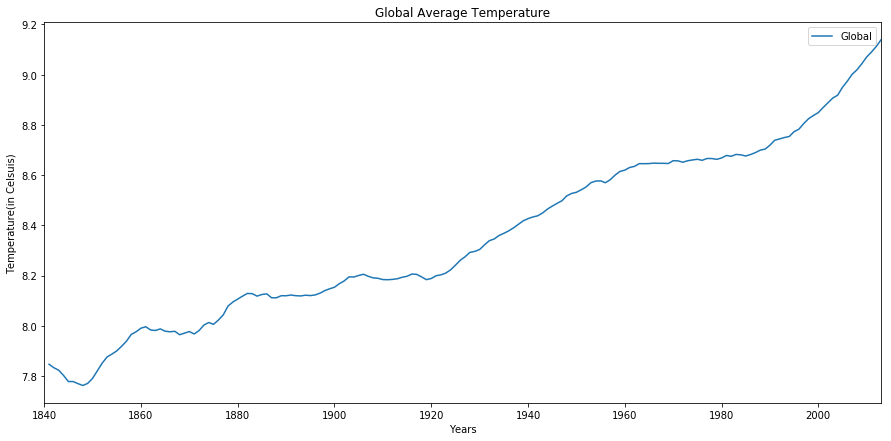

```python
plt.figure(figsize=(15,7))
plt.plot('year','MA-G',data = common[common["year"]>1840], label = 'Global')
plt.legend()
plt.xlabel("Years")
plt.ylabel("Temperature(in Celsuis)")
plt.title("Global Average Temperature")
plt.xlim(1840,2013)
plt.show()
```

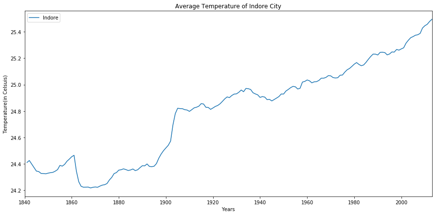

```python
plt.figure(figsize=(15,7))
plt.plot('year','MA-I',data = common[common["year"]>1840], label = 'Indore')
plt.legend()
plt.xlabel("Years")
plt.ylabel("Temperature(in Celsuis)")
plt.title("Average Temperature of Indore City")
plt.xlim(1840,2013)
plt.show()
```

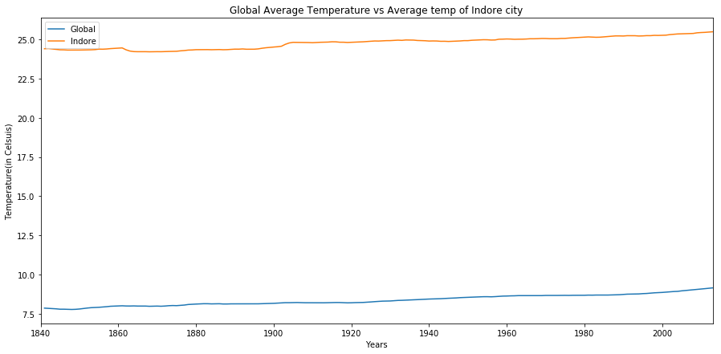

```python
plt.figure(figsize=(15,7))
plt.plot('year','MA-G',data = common[common["year"]>1840], label = 'Global')
plt.plot('year','MA-I',data = common[common["year"]>1840], label = 'Indore')
plt.legend()
plt.xlabel("Years")
plt.ylabel("Temperature(in Celsuis)")
plt.title("Global Average Temperature vs Average temp of Indore city")
plt.xlim(1840,2013)
plt.show()
```

### OBSERVATIONS:

##### Now let us compare the temperature rise in the major cities around the world. We've considered Moving Average window as 10 years so as to better understand the variation in average temperature at various places. Also, instead of interpolation method, we're using mean of all the average temperatures to fill the missing values.

```python
Antananarivo = pd.read_csv('C:/Users/shrey/Desktop/UDACITY/Project1/Antananarivo.csv')
```

```python
Cordoba = pd.read_csv('C:/Users/shrey/Desktop/UDACITY/Project1/Cordoba.csv')
```

```python
LA = pd.read_csv('C:/Users/shrey/Desktop/UDACITY/Project1/LA.csv')
```

```python
London = pd.read_csv('C:/Users/shrey/Desktop/UDACITY/Project1/London.csv')
```

```python
Ottawa = pd.read_csv('C:/Users/shrey/Desktop/UDACITY/Project1/Ottawa.csv')
```

```python
Perth = pd.read_csv('C:/Users/shrey/Desktop/UDACITY/Project1/Perth.csv')
```

```python
Tokyo = pd.read_csv('C:/Users/shrey/Desktop/UDACITY/Project1/Tokyo.csv')
```

```python
Singapore = pd.read_csv('C:/Users/shrey/Desktop/UDACITY/Project1/Singapore.csv')
```

```python
Helsinki = pd.read_csv('C:/Users/shrey/Desktop/UDACITY/Project1/Helsinki.csv')
```

```python
London = London.fillna(London['avg_temp'].mean())
Ottawa = Ottawa.fillna(Ottawa['avg_temp'].mean())
LA = LA.fillna(LA['avg_temp'].mean())
Perth = Perth.fillna(Perth['avg_temp'].mean())
Antananarivo = Antananarivo.fillna(Antananarivo['avg_temp'].mean())
Cordoba = Cordoba.fillna(Cordoba['avg_temp'].mean())
Tokyo = Tokyo.fillna(Tokyo['avg_temp'].mean())
Singapore = Singapore.fillna(Singapore['avg_temp'].mean())
Helsinki = Helsinki.fillna(Helsinki['avg_temp'].mean())
```

```python
Tokyo['MA-Tokyo'] = Tokyo.avg_temp.rolling(11).mean()
Cordoba['MA-Cordoba'] = Cordoba.avg_temp.rolling(11).mean()
Ottawa['MA-Ottawa'] = Ottawa.avg_temp.rolling(11).mean()
Antananarivo['MA-Antananarivo'] = Antananarivo.avg_temp.rolling(11).mean()
Perth['MA-Perth'] = Perth.avg_temp.rolling(11).mean()
LA['MA-LA'] = LA.avg_temp.rolling(11).mean()
London['MA-London'] = London.avg_temp.rolling(11).mean()
Singapore['MA-Singapore'] = Singapore.avg_temp.rolling(11).mean()
Helsinki['MA-Helsinki'] = Helsinki.avg_temp.rolling(11).mean()
```

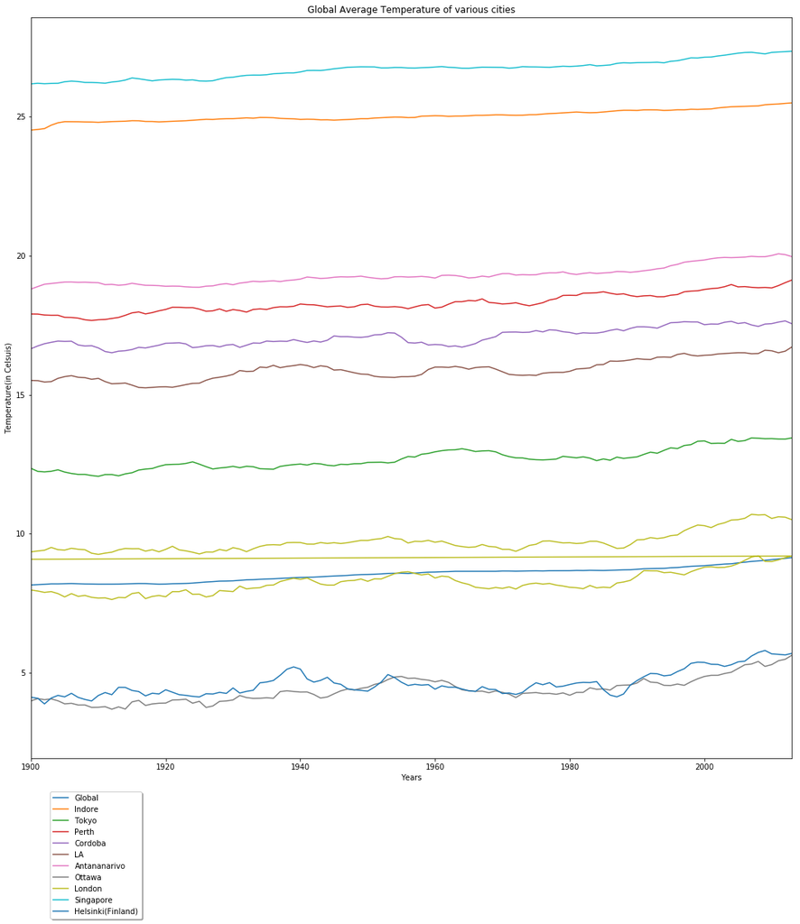

```python
plt.figure(figsize=(18,18))
plt.plot('year','MA-G',data = common[common["year"]>1845], label = 'Global')
plt.plot('year','MA-I',data = common[common["year"]>1845], label = 'Indore')
plt.plot('year','MA-Tokyo',data = Tokyo[Tokyo["year"]>1845], label = 'Tokyo')
plt.plot('year','MA-Perth',data = Perth[Perth["year"]>1845], label = 'Perth')
plt.plot('year','MA-Cordoba',data = Cordoba[Cordoba["year"]>1845], label = 'Cordoba')
plt.plot('year','MA-LA',data = LA[LA["year"]>1845], label = 'LA')
plt.plot('year','MA-Antananarivo',data = Antananarivo[Antananarivo["year"]>1845], label = 'Antananarivo')
plt.plot('year','MA-Ottawa',data = Ottawa[Ottawa["year"]>1845], label = 'Ottawa')
plt.plot('year','MA-London',data = London[London["year"]>1845], label = 'London')
plt.plot('year','MA-Singapore',data = Singapore[Singapore["year"]>1845], label = 'Singapore')
plt.plot('year','MA-Helsinki',data = Helsinki[Helsinki["year"]>1845], label = 'Helsinki(Finland)')
plt.legend( bbox_to_anchor=(0.15, -0.04),fancybox=True, shadow=True)
plt.xlabel("Years")
plt.ylabel("Temperature(in Celsuis)")
plt.title("Global Average Temperature of various cities")
plt.xlim(1900,2013)
plt.show()
```

### OBSERVATION:

We can see that cities further towards the pole have much noisier curve. Thus, it can be concluded that cities/places away from equator are facing more average temperature variations than those near the equator.